# Intergroup Cooperation under Unevenly Distributed Futures

Author

Thao-Nguyen Ha (Vanderbilt University); Ted Ledford (UIUC)

Published

May 28, 2026

# 1 Scenario

A society composed of both humans and an alien species can only interact with one another (both within and across groups) by sending emails (they speak a common language). Model this system as the various agents learn to cooperate with one another while avoiding any pitfalls.

# 2 Problem introduction

Ensuring the survival of a species often requires innovation that allows the species to better adapt to environmental changes. However, making scientific progress is often a cooperative endeavor. The assumption is simple: the more resources and personnel devoted to science, the higher the likelihood that a scientific breakthrough is achieved. The catch is that most societies, countries, or species have divergent incentives in scientific investment. To start, science can be a common good that benefits everyone, which generates free-riding incentives. Science can also be a club good, which serves the interests of a specific group rather society as a whole.

We propose a scenario where a planet is coinhabited by two species (humans and aliens). The planet faces the certainty of impending doom without intervention. Humans and alien scientists must strategically decide how to expend their resources independently in order to select and advance a successful strategy for survival. There are three pathways. One reliable option is members from each species can pursue scientific advancement toward an ‘exit strategy’. For example, both species could invest in building their own spaceship to escape to a new planet. Somewhat to how Earth billionaires are interested in space travel, this advancement benefits only their member group, while leaving the other group behind. An alternative is for both aliens and humans to cooperatively develop scientific “breakthroughs” that revert the doomsday deadline. The more scientists working on science, the more likely a scientific breakthrough happens. Yet science comes at the expense of exit. The central question is thus:

- Under what conditions will both species cooperate on scientific endeavors, and how likely are they to revert the doomsday scenario?

# 3 Model setup

## 3.1 Initialization

- The world spawns **N = 100 agents** who are scientists, of which some are humans and some aliens.
- **Lifespans**: Each agent scientist has their own life expectancy. In general, aliens live longer than humans; humans’ life expectancy is drawn based on a uniform distribuion `U~[20, 80]`, while alien scientists have `U~[70, 180]` years left to live. The lifespan is better interpreted as the time horizon of each agent.
- **Doomsday clock**: at initialization, Nature draws `y ~ U[40, 200]` — the year the planet becomes uninhabitable. Each tick represents one year.

## 3.2 Model sequence

At the start of each period:

1. **Nature draws the true state** `beta ~ U[0, 1]`, representing the correct experimental instructions needed for a scientific breakthrough.
2. **Each active agent receives a noisy private signal**:

   ```
   delta_i = beta + eps_i
   ```

   - Humans: `eps_H ~ U[-0.25, 0.05]` (negatively biased)
   - Aliens: `eps_A ~ U[-0.05, 0.25]` (positively biased)
3. **A revealer is selected** at random. The revealer observes the true `beta` and chooses to lie or tell the truth based on their personal stake in planet survival:

   ```
   rem        = revealer's remaining natural life       (L_species - age)
   until_ext  = years until extinction                  (y - t)
   urgency    = max(0, rem - until_ext) / max(rem, 1)   ∈ [0, 1]
   p_lie      = 1 − urgency
   ```

   With probability `p_lie`, the revealer **lies**: `broadcast = beta + sign · lie_magnitude` where `sign` is uniform on `{−1, +1}`. With probability `1 − p_lie`, the revealer is **honest**: `broadcast = beta`. The revealer always broadcasts (no silence option).

This allows us to separate the sender into types based on the level of *urgency*: an agent who may live longer than the expected doomsday therefore have more incentive to encourage science.

4. **Listeners update beliefs** about `beta` using a Bayesian approach. Each agent computes a posterior mixture over revealer types, inferring what true `beta` would produce the observed broadcast; outputs a posterior mean and signal credibility.
5. Agents then choose between investing in the scientific experiment or investing in the exit option.
6. The round ends and all agents’ life expectancies decrease by 1. The planet reaches extinction if tick time `t >= y`. Additional simulation also ends at full depopulation, or when `max_ticks = 600`.

## 3.3 Assumptions

**Exit means are species-specific.** Aliens and humans can only build rockets optimal for their own species’ attributes.

**No do nothing option.** All agents must choose either planet-saving science or rocket science.

**Science.** When an agent chooses to invest in planet-saving science, implement experimental instructions `delta_i` (or `effective_instr` if broadcast is trusted).

```
EU_{science} = p_break * min(rem, until_ext + breakthrough_gain)
       + (1 - p_break) * min(rem, until_ext)
       - k_cost / c_i
       - (1 - personal_quality) * wrong_penalty
```

where

- `rem` = remaining natural lifespan
- `until_ext` = years until extinction (`y - t`)
- `c_i` = agent capability (in extended model; `c_i = 1` in base model)
- `p_break = g(n_expected) * personal_quality`; agents assume half of active agents join
- `personal_quality = sig_quality * c_i` (capability-weighted signal quality)
- `g(n) = g_max * (1 - (1 - p0)^n)`, capped at `g_max = 0.35`; `p0 = 0.005`
- `k_cost / c_i` (capability-adjusted; low capability → expensive), `wrong_penalty = 1.5`

**Exit.** Instead of investing into science, agents can contribute `s = 1` to an exit fund (e.g. building a rocket, digging a sanctuary). Once the exit fund surpasses a threshold, the whole species leaves the planet.

```
EU_exit = cross_prob * q_exit * rem - c_exit
```

**Scientific production function.** Science is costly but isn’t always successful. Each period, if any agents chose Science:

```
p_breakthrough = g(n_sci) * h(effective_instr, beta, tau)
```

- `g(n_sci) = g_max * (1 - (1 - p0)^n_sci)`: increasing, concave in the number of scientists, capped at `g_max = 0.35`
- `h(...)`: fraction of scientists whose `effective_instr` is within their capability-adjusted window `tau * c_i` of the true `beta`
- **Breakthrough outcome**: if drawn successfully, `y += breakthrough_years_gain = 20` (twenty more years of planet life)
- **Wrong experiments**: scientists outside the `tau` window each reduce `y` by `1.5` years (`wrong_exp_penalty`)

Each agent draws a capability $c_i \sim U[c_{\text{low}}, c_{\text{high}}]$ at initialization, with species-specific ranges. Capability modulates three aspects of the science action:

1. **Cost**: `k_i = k_cost / c_i`. Low-capability agents face higher costs.
2. **Success window**: agent $i$ contributes to `h(.)` if `|effective_instr - beta| <= tau * c_i`. Low-capability agents need higher signal accuracy to succeed.
3. **Personal quality**: `personal_quality_i = sig_quality_i * c_i`. Low-capability agents estimate lower expected contribution to breakthroughs, and face higher wrong-experiment risk `(1 - personal_quality) * wrong_penalty`.

## 3.4 Parameters

| Parameter | Default | Description |
| --- | --- | --- |
| `N` | 100 | Population size |
| `frac_human` | 0.5 | Fraction of agents who are Human |
| `H`, `A` | -0.10, 0.10 | Species bias centers |
| `Delta` | 0.15 | Half-width of species noise window |
| `tau` | 0.05 | Breakthrough success radius |
| `p0` | 0.005 | Per-scientist baseline success rate |
| `s` | 1.0 | Per-period exit contribution |
| `q_exit` | 0.6 | Escape success probability once threshold crossed |
| `c_exit` | 1.0 | Sunk cost when choosing exit |
| `x_bar` | 2000 (sweep range 500–12000) | Cumulative exit threshold |
| `k_cost` | 0.8 | Cost to participate in science |
| `breakthrough_years_gain` | 20.0 | Years added per breakthrough |
| `wrong_exp_penalty` | 1.5 | Years lost per wrong scientist |
| `y_low`, `y_high` | 40, 200 | Doomsday clock range (Nature draws `y ~ U[y_low, y_high]`) |
| `L_H`, `L_A` | 80, 200 | Human and Alien lifespans |
| `age_H_low`, `age_H_high` | 0, 60 | Initial human age range (so `rem_H ~ U[20, 80]`) |
| `age_A_low`, `age_A_high` | 20, 130 | Initial alien age range (so `rem_A ~ U[70, 180]`) |
| `lie_magnitude` | 0.20 | `\|broadcast − beta\|` when a revealer lies |
| `eu_temperature` | 0.0 | Softmax temperature (0 = deterministic) |
| `g_max` | 0.35 | Ceiling on `g(n_sci)`: irreducible per-period failure risk |
| `c_H_low`, `c_H_high` | 0.3, 1.0 | Human capability range |
| `c_A_low`, `c_A_high` | 0.3, 1.0 | Alien capability range |

(As of this version, capability range is the same across species, but we could imagine an extension in which there is human- or alien-biased scientific directive.)

## 3.5 Outputs

To get at our questions, our experimental runs produce visualizations on several outcomes of interests. Each run therefore records:

- **Outcome at end state**: terminal reason (`extinction`, `depopulated`, `maxticks`), final `t`, `y`
- **Science output**: number of breakthroughs, wrong experiments, years lost to wrong experiments
- **Exit viability**: cumulative investment per species, whether each species escaped
- **Cooperation**: `coop_index` (time-averaged `min(science-share H, science-share A)` over periods where both species are alive — 1 means both species fully participate, 0 means at least one species does no science), `effort_balance`, `survival_balance`
- **Survival**: alive and escaped counts per species
- **Capability**: mean capability of scientists vs exiters, per-species mean capability

For each set of parameters, we conduct 1000 simulations.

## 3.6 Comments on the model

The model has flavors of both a Stag Hunt and Prisoners’ Dilemma. Because individual agents vary in how much they value the planet against their life expectancies, the chosen messenger may be inclined to broadcast message that manipulates the decisions of both their own ingroup and outgroup scientists. Science is resource intensive, though possibly beneficial over time. The longer it takes for its benefits to accrue at the expense of pursuing an exit option, the less confidence a species will have in its success and adoption. This is because the preference for the strategy will extend beyond their lifespan, making the immediacy and lower threshold for an exit strategy more attractive. What is key here, is how soon both species can learn to pursue a shared scientific strategy of with progress accruing reliably by both groups, allowing each to stay through the end of their lifespan. However, this is complicated when lifespans between species differ, and the urgency of exit and rewards of cooperation are tested by shorter lives with less patience.

# 4 Results and discussion

The most immediate and obvious result is that the further away the doomsday, scientific endeavors flourish. This suggests that the problem is more about coordination, and free-riding incentives do not seem to dominate.

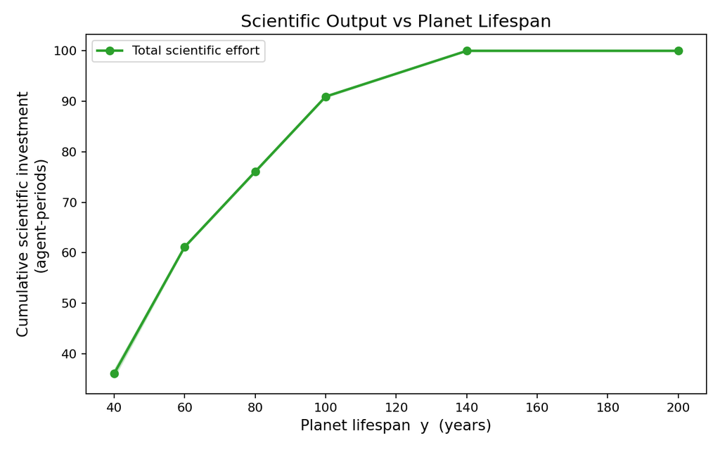

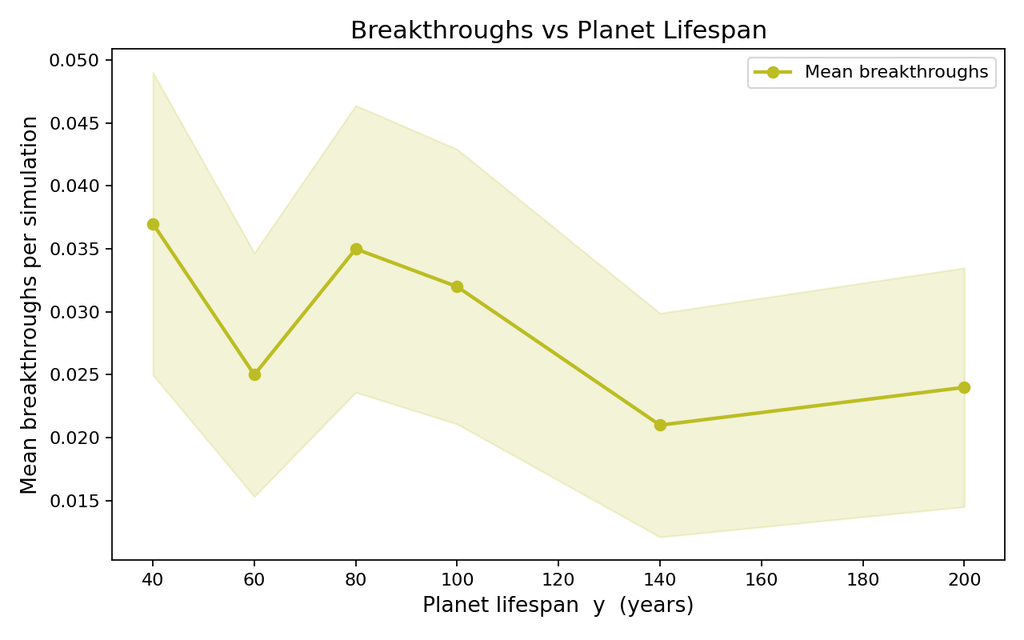

Figure 2: Mean rate of scientific breakthroughs per simulation

The model outputs reveal a few more strategic tradeoffs that were not immediately obvious at the outstart. Aside from the original coordination problems, scientific progress juggles a fine balance between quality and quantity. Scientific breakthroughs depend on the capability of individual scientist, but also the (fixed) cost of each experimental conduct. Higher costs therefore weed out low-quality scientists, who refrain from conducting the experiment because they know it would fail anyway. Remaining scientists conduct the experiment and see higher success rates, but this increase does not outweigh the loss in the number of active scientists.

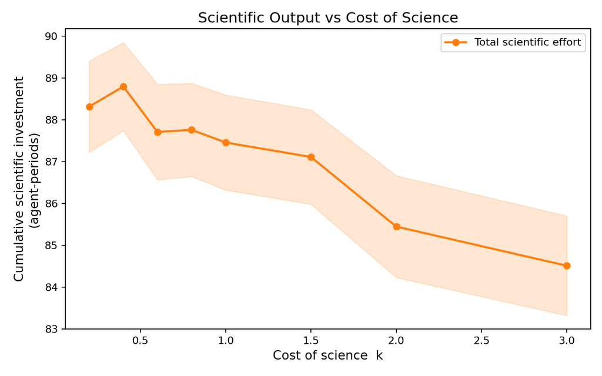

Figure 3: Scientific output changes as the cost of experiment varies.

# 5 Real-life application

Our model opens up several inquiries that are highly relevant for not only interstellar explorations, but also human interactions within our planet Earth.

First, as a collective scientific commmunity, is it always better invest time into coordinating your knowledge with others for greater expected results. At what point does sticking with what you already know make more optimal sense? In practice, the trade off costs you marginal gains at the end of your life.

At the same time, could your aversion to innovate deprive society from long term gains? Comparatively, for institutions, there is no clear path for scientific advancement. The rewards and costs, and likelihood for marginal gains versus breakthrough, are notoriously difficult to anticipate. Furthermore, a society must face the cost and uncertainty of aligning science toward compatible technological applications that advance mutual goals and interests. A society might expect that its scientific community focus on strategies that pair science within their own traditions/conceptual foundations (minimal risk) with outcomes channeled to an existing technological problem space/framework (anticipated rewards). Or a scientific community might be granted freedom to adopt less established ideas, that deviate from local tradition, require costly or unavailable resources and offer less immediate social benefits and technological translation. When time and the availability of scientists is scarce, societies must be strategic when choosing whether they are equipped to pursue similar research agendas from their counterparts, or face asymmetric results.